# Organize Your Files and Metadata for Transparent and Reproducible Research

Fall 2021

## Slides Usage Notes

- Recommended to press `w` for widescreen view.
- Also recommended to press `f` for fullscreen view.
- Press `p` for Presenter Notes.
- These slides are licensed as CC-BY.

## Introduction: A Bad Example

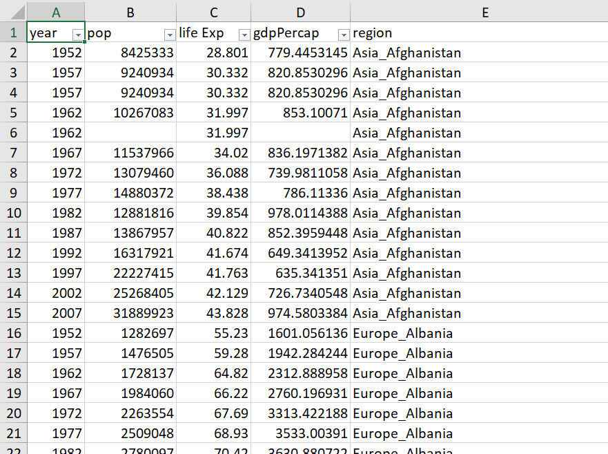

Example of a poorly described Excel file

## We can do better!

1. Project file organization
2. README
3. Descriptive and “friendly” files names

## Project Organization

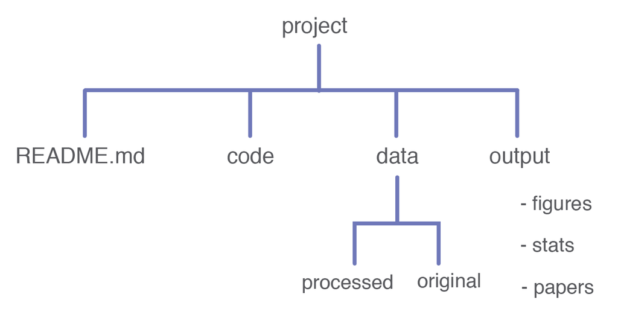

Image credit: https://reproducible-science-curriculum.github.io/

## `project` directory

- This is the top-level directory
- All files related to a project live in this one directory
- Give the project directory a meaningful name related to your research project

## `code` sub-directory

- Separate code into its own directory.
- Other common names for this directory:
  - Scripts
  - Source or src
  - Command_files
  - R
- Depending on the complexity of your project, you might want to separate:
  - Analysis code
  - Function definitions

## `data` sub-directory

- You must identify which data files are:
  - Original (aka raw aka source) data
    - Treat as read-only!
  - Modified: either programmatically or manually edited
    - Treat as disposable.

## `output` sub-directory

- This sub-directory contains files generated from other files.
- Examples include:
  - Plots
  - Tables

## `documents` or `reports` sub-directory

- Lastly, you need a place for your documents or reports - basically any textual report that you might write in relation to the project.
- Keep in mind these are outwardly facing files (for an advisor, academic readers, clients, etc.). Keep this separate from your data and code, as those are internally facing work files.

## Key Points

- Distinguish between file types.
- Record modifications.
- More art than science.

## Identify Output Files

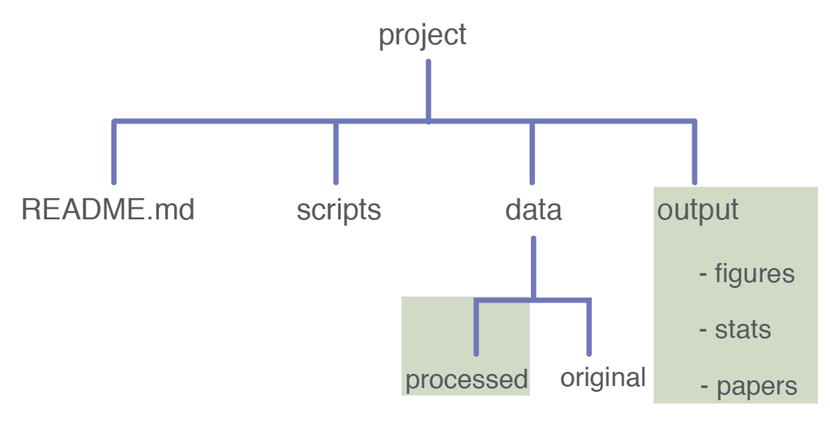

Image credit: https://reproducible-science-curriculum.github.io/

## More Examples…

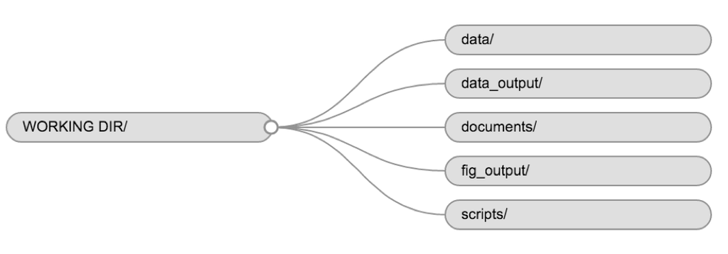

Image credit: https://datacarpentry.org/r-socialsci/00-intro/index.html

## A more complex example

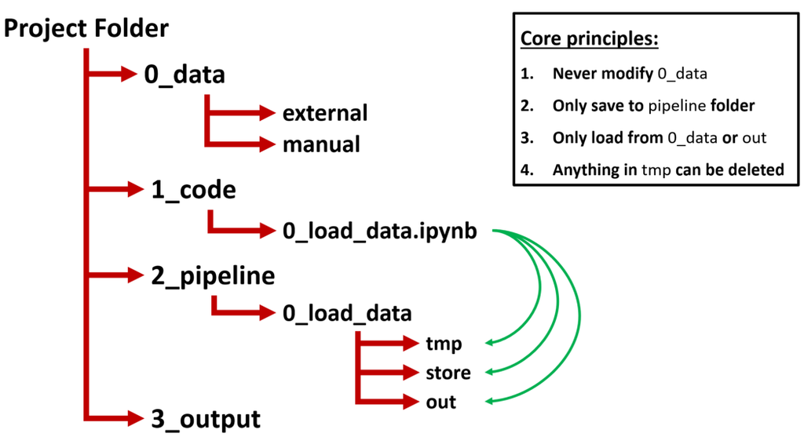

Image credit: Ties de Kok: [How to keep your research projects organized, part 1: folder structure](https://towardsdatascience.com/how-to-keep-your-research-projects-organized-part-1-folder-structure-10bd56034d3a).

## Automate your folder structure

[figure not shown]

## Project Organization

- **Good**. Separate input and code from output using different folders or file names and keep track of all the input->output changes in separate files.
- **Better**. Consistent folder structure across projects. Read-only raw data
- **Best**. Script to generate folder structures, Version control READMEs and scripts to track modifications

## Build out a Project Structure with Explorer/Finder

And then visit bit.ly/org4repro

## README: just a little bit of documentation

## `README` file

- A README gives users important information about a project.
- Should be in plain text format (either plain text/.txt or Markdown/.md)

Useful README file content:

1. Project name
2. Useful dates (date project began, date last updated)
3. Author names and contact info
4. Origin of data
5. 3-4 sentences about the goal of the project
6. Dependencies / How to Install / Project Structure

## Example README in Markdown

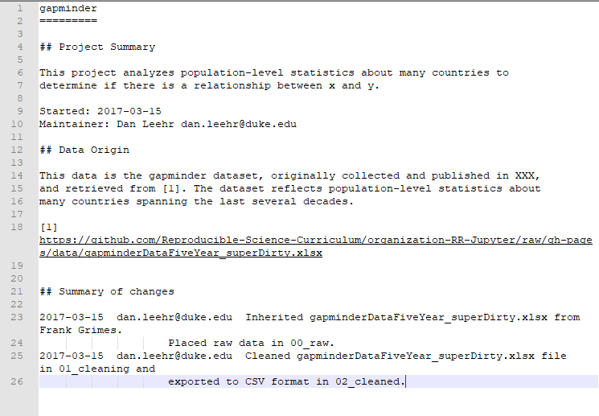

## README: Good, Better, Best

- **Good**. Plain text.
- **Better**. Date, name, contact info, short summary, Markdown.
- **Best**. Include history of all changes to the project.

## Naming Files

## Names Matter

Three principles for files names:

- Human readable
- Machine readable
- Plays well with default ordering

## Human readable

- Names indicate content
  - 01_data-cleaning.R
  - 02_visualization.R
- Vs.
  - 01.R
  - 02.R
- Easy to figure out based on the name

## Naming conventions: Use names to convey order

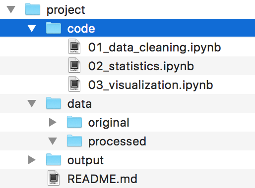

## Naming conventions: Use names to convey history

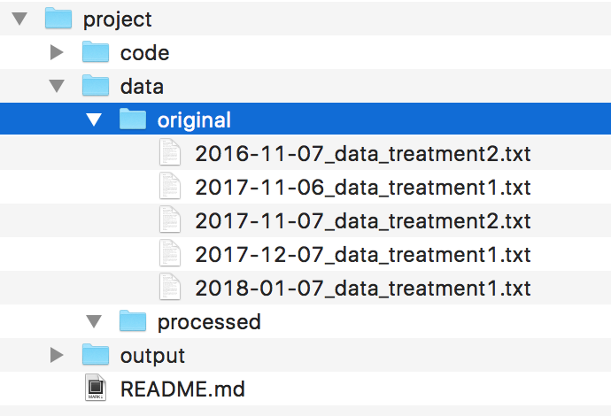

## Machine readable

- Make it easy to search for files later
  - Via regex or through your operating system’s search functionality
- Avoid these in file names:
  - Spaces
  - Punctuation except `-` and `_`
  - Accented characters
- Do use:
  - A consistent capitalization scheme, i.e., don’t include the names foo and Foo in the same project
  - Seperate units of metadata with `_` – use it as a delimiter for regex
  - Use `-` within units of metadata for easier human readability

## Example of advanced technique: “globbing”

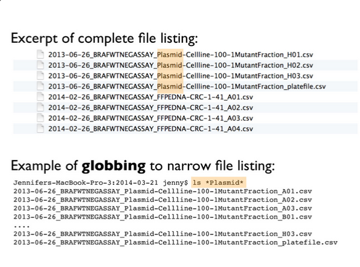

Image credit: Jenny Bryan: https://speakerdeck.com/jennybc/how-to-name-files?slide=7

## Example of advanced technique: recover metadata

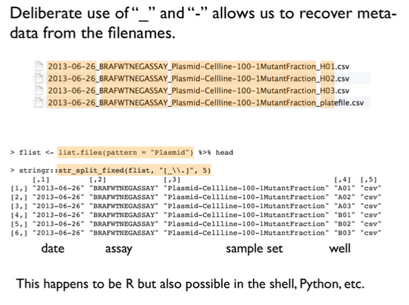

Image credit: Jenny Bryan https://speakerdeck.com/jennybc/how-to-name-files?slide=10

## Plays well with default ordering

This means that when you look at project files in your directory, the files undergo default ordering in the display

- Put numeric info first
- For logical order: Left pad numbers with zeros
- For chronological order: Use date format: YYYY-MM-DD

## Default ordering: Left pad numbers with zeros

Like so:

- 01_cleaning.R
- 02_visualization.R
- 10_final-figures.R

If you don’t, it could lead to this order:

- 10_final-figures.R
- 1_cleaning.R
- 2_visualization.R

## Default ordering: ISO 8601 date standard

Use YYYY-MM-DD. Leads to far less confusion among humans. Machines will always interpret this correctly. Default ordering will work correctly every time.

Yes:

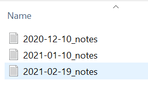

No:

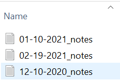

## File names: Good, Better, Best

- **Good**. Use descriptive file/directory names that convey function and history.
- **Better**. ISO 8601 date stamps in file and directory names. Use numbers (with left-padding) to indicate order of scripts.
- **Best**. Seperate units of metadata with `_` (underscrore) for regex. Within units of metadata, use `-` (hyphen or dash) for human readability.

## Organization case study

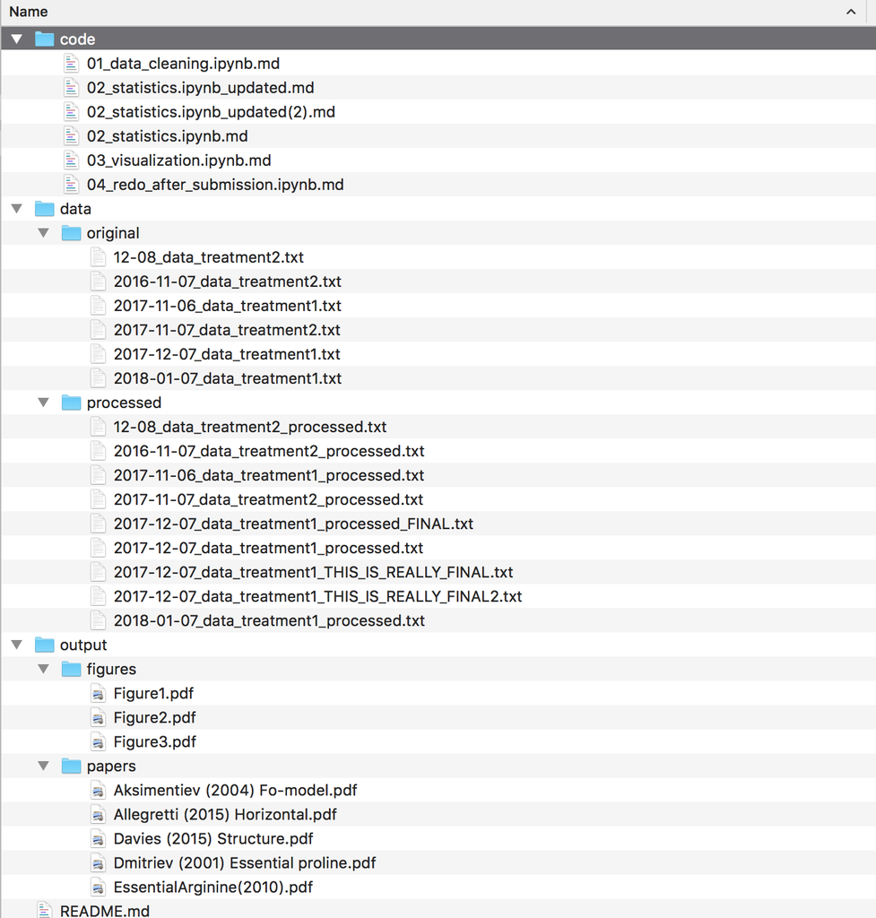

## One more example, with named files

[figure not shown]

Image credit: @jessenleon

## In sum, good project organization and file names…

- Are easy to implement now.
- Payoff the more complicated your projects get, and the better your skills become:
  - File names: if you do find yourself needing to use regex to call files
  - Project organization: reflects what you need to do anyway when compiling R packages
- Make your life easier!

## Credits

Much of the Project Organization and README material has been adapted from: Reproducible Science Curriculum: Data & Project Organization: https://reproducible-science-curriculum.github.io/organization-RR-Jupyter/

Much of the file naming material has been adapted from: Jenny Bryan. How to Name Files. https://speakerdeck.com/jennybc/how-to-name-files

## Further References

Project TIER. TIER Protocol 3.0. https://www.projecttier.org/tier-protocol/specifications-3-0/

Data Carpentry. R for Social Scientists: Before We Start. https://datacarpentry.org/r-socialsci/00-intro/index.html.

Data Carpentry. File Organization: https://datacarpentry.org/rr-organization1/.

Data Carpentry. Reproducible Research in R Workshop Overview. https://datacarpentry.org/rr-workshop/

Dryad. Best Practices for creating reusable data publications: Organize files in a logical schema. https://datadryad.org/stash/best_practices#organize

Martin Chan. 2020. “RStudio Projects and Working Directories: A Beginner’s Guide.” Musings on R. https://martinctc.github.io/blog/rstudio-projects-and-working-directories-a-beginner's-guide/

Leon Jessen. 2018. https://twitter.com/jessenleon/status/964236119658418176 and How to organize a project: The most important talk you never heard! https://github.com/leonjessen/talks

Ties de Kok. How to keep your research projects organized, part 1: folder structure. https://towardsdatascience.com/how-to-keep-your-research-projects-organized-part-1-folder-structure-10bd56034d3a

Greg Wilson, et al. “Good enough practices in scientific computing.” PLOS Computational Biology. 2017. https://journals.plos.org/ploscompbiol/article?id=10.1371/journal.pcbi.1005510#pcbi.1005510.ref001

Noble, W. S. “A Quick Guide to Organizing Computational Biology Projects.” PLOS Computational Biology. 2009. https://journals.plos.org/ploscompbiol/article?id=10.1371/journal.pcbi.1000424

Jenny Bryan. How to name files. https://speakerdeck.com/jennybc/how-to-name-files

Rich Fitzjohn. Designing Projects. https://nicercode.github.io/blog/2013-04-05-projects/

Chris Von Csefalvay. Structuring R Projects. https://chrisvoncsefalvay.com/2018/08/09/structuring-r-projects/ (Note: best source for more complicated data science projects.)

Krista L. DeStasio. R Best Practices. https://kdestasio.github.io/post/r_best_practices/#fn1